# Script3_Armbruster2026_NormalizationClusteringAnnotation

Daniel Armbruster

2026-07-24

- In this script we performed normalization, cell cycle correction, dimensionality reduction, clustering, and annotation of the filtered RDS file we generated in Script 2.
- Additionally, we calculated data on the differentially expressed genes and extracted differenitally expressed transcription factors which are part of Table S1. Also, in this script we generated the visualizations of Figure 1C-D and Figure S2A-D.
- Moreover, we characterized neurotransmitter and neuropeptide production/reception signatures across clusters and generated the corresponding visualization depicted in Figure 6A and B as well as the associated data presented in Table S6C-E and Table S6J-L.
- The session info including the used packages and their versions is provided at the end of this script.

# 1. Load Packages

```r
library(Seurat)
library(AnnotationHub)
library(dplyr)
library(ggplot2)
library(readr)
library(cowplot)
library(openxlsx)
library(stringr)
```

# 2. Load data

```r
cells_singlets <- readRDS(file = "RDS_files/Script2_Armbruster2026_singlets.rds")
```

# 3. Pre-processing for normalization and clustering

```r
#Removal of EGFP & E2AQF2 genes as we don't want that they drive clustering
counts <- GetAssayData(cells_singlets, slot = "counts")
counts2 <- counts[-(which(rownames(counts) %in% "EGFP")),]
cells_singlets <- subset(cells_singlets, features = rownames(counts2))
counts <- GetAssayData(cells_singlets, slot = "counts")
counts2 <- counts[-(which(rownames(counts) %in% "E2AQF2")),]
cells_singlets <- subset(cells_singlets, features = rownames(counts2))

#Remove cluster info assigned during doublet removal from the metadata
cells_singlets$seurat_clusters <- NULL
cells_singlets$RNA_snn_res.0.8 <- NULL
cells_singlets <- SetIdent(cells_singlets, value = "orig.ident")
```

# 4. Assessing cell cycle variances

## 4.1 Cell cycle scoring

```r
# Normalization to account for differences in sequencing depth
cells_singlets_phase <- NormalizeData(cells_singlets)
```

```
## Normalizing layer: counts
```

- Cell cycle effects on clustering are assessed by calculating the S phase and G2/M phase scores using zebrafish cell cycle marker genes derived from the Harvard Chan School (Bioinformatics Core) github repository: https://github.com/hbc/tinyatlas/blob/master/cell_cycle/Danio_rerio.csv

```r
# Load cell cycle marker table. Cell cycle gene list derived from https://github.com/hbc/tinyatlas/blob/master/cell_cycle/Danio_rerio.csv
ccgenes <- read.csv(file = "Resources/DanioRerio_CellCycle.csv")

# Create AnnotationHub
ah <- AnnotationHub()

# Access the Ensembl database for Danio Rerio
ahDb <- query(ah,pattern = c("Danio rerio", "EnsDb"),ignore.case = TRUE)

# Zebrafish 10.91  has  Ensembl  ID "AH60762"
id <- "AH60762"

# Load data
edb <- ah[[id]]
```

```
## loading from cache
```

```
## require("ensembldb")
```

```r
#Extract the gene-level information from the database:
annotations <- genes(edb, return.type = "data.frame")
annotations <- annotations %>% dplyr::select(gene_id, gene_name, seq_name, gene_biotype, description)

# Connect EnsemblIDs to gene info
ccmarkers <- dplyr::left_join(ccgenes, annotations, by = c("geneID" = "gene_id"))

# Get gene names of the S phase markers
s_markers <- ccmarkers %>% dplyr::filter(phase == "S") %>% pull("gene_name")
s_markers
```

```
##  [1] "mcm6"   "cdc45"  "msh2"   "mcm5"   "pola1"  "mcm4"   "gmnn"   "rpa2"
##  [9] "hells"  "e2f8"   "gins2"  "pcna"   "nasp"   "brip1"  "dscc1"  "dtl"
## [17] "cdca7a" "chaf1b" "usp1"   "slbp"   "rrm1"   "fen1"   "exo1"   "tyms"
## [25] "uhrf1"
```

```r
# Get gene names of the G2M phase markers
g2m_markers <- ccmarkers %>% dplyr::filter(phase == "G2/M") %>% pull("gene_name")
g2m_markers
```

```
##  [1] "tpx2"   "birc5a" "g2e3"   "cbx5"   "ctcf"   "ttk"    "smc4"   "nek2"
##  [9] "cenpf"  NA       "top2a"  "cdca8"  "nusap1" "kif11"  "anp32e" "lbr"
## [17] "ccnb2"  "hmgb2a" "cdk1"   "cks1b"  "ckap5"
```

- Cell cycle scoring

```r
# Calculate S phase and G2/M phase scores for each cell
cells_singlets_phase <- CellCycleScoring(cells_singlets_phase, g2m.features = g2m_markers, s.features = s_markers)
# Identify the most variable genes
cells_singlets_phase <- FindVariableFeatures(cells_singlets_phase, selection.method = "vst", nfeatures = 2000, verbose = FALSE)

# Scale the counts
cells_singlets_phase <- ScaleData(cells_singlets_phase)
# Perform PCA
cells_singlets_phase <- RunPCA(cells_singlets_phase)
```

```
## PC_ 1
## Positive:  aldob, krt8, si:ch211-105c13.3, zgc:162730, eef1da, krt4, FO904881.1, lgals3b, sepp1a, s100a10b
##     ahnak, eef1a1l2, lxn, slc38a5b, RPL41, gsta.1, rpl34, rpl23a, rps6, ube2e1
##     rpl7a, rps10, rpl12, rps2, rps12, rpl36a, rpl8, rpl35a, rpl13, rps28
## Negative:  gngt2b, gnb3b, si:ch73-28h20.1, tmem237a, rp1l1b, arr3b, ncaldb, rbp4l, si:ch1073-469d17.2, syt5a
##     aqp9b, ckmt2a, slc25a3a, crx, elovl4b, si:ch211-285j22.3, si:dkeyp-57d7.4, si:dkey-17e16.15, pde6h, ckmt2b
##     inaa, arl3l2, camk1gb, irbp, mef2ca, si:ch211-81a5.8, si:ch211-160o17.6, rpgra, ppdpfa, ndrg1a
## PC_ 2
## Positive:  gngt2b, tmem237a, gnb3b, si:ch73-28h20.1, rp1l1b, arr3b, si:ch1073-469d17.2, rbp4l, ncaldb, syt5a
##     ckmt2a, slc25a3a, aqp9b, elovl4b, crx, si:dkeyp-57d7.4, si:dkey-17e16.15, si:ch211-285j22.3, ckmt2b, ppdpfa
##     pde6h, irbp, inaa, ndrg1a, arl3l2, si:ch211-160o17.6, mef2ca, camk1gb, si:ch211-81a5.8, rpgra
## Negative:  snap25a, elavl4, scg5, hmgn2, scg2b, fosab, cplx1, tubb5, mao, tmsb
##     hpca, sncgb, map1ab, syt2a, slc35g2a, egr4, ndrg4, phox2bb, junbb, cplx2
##     frmpd3, slc17a6b, phox2a, gch1, nell2b, slc6a2, slc31a1, scg2a, dbh, tfap2a
## PC_ 3
## Positive:  FO904881.1, krt4, si:dkey-248g15.3, wu:fb18f06, s100w, si:dkey-33i11.9, zgc:153284, s100v1, s100a10b, cfl1l
##     icn, si:ch211-105c13.3, capgb, si:ch211-117m20.5, spint2, epcam, si:ch211-195b11.3, cldnb, gsto2, stard14
##     cldne, tprg1, ppl, anxa1a, si:dkey-74k8.3, agr1, si:ch211-125o16.4, si:dkey-87o1.2, cyt1, lye
## Negative:  col5a1, col1a2, col1a1a, col1a1b, sparc, mfap2, pmp22a, dcn, col2a1b, col6a2
##     col6a3, mxra8b, fmoda, col6a1, col6a4a, col5a2a, pdgfra, si:ch1073-291c23.2, col11a1a, mmp14a
##     aspn, colec12, tgfbi, si:ch211-286o17.1, ENSDARG00000028618, mmp2, ifitm1, serpinh1b, pdgfrl, col11a1b
## PC_ 4
## Positive:  slc6a2, dbh, elavl4, phox2a, syt2a, phox2bb, slc17a6b, slc31a1, ngfra, hoxb3a
##     sncgb, tfap2a, si:dkey-7j14.5, ntng1a, sall3a, slc35g2a, bdnf, adra2c, nell2b, map1ab
##     atp1b1a, raraa, hoxb5b, tfap2b, mab21l2, hoxb5a, ENSDARG00000020655, scg2b, hoxa4a, meis2b
## Negative:  prdx1, pou3f1, zgc:56493, scgn, zgc:162707, dlx5a, CRACR2A, sox1a, nkx2.4b, otofa
##     si:ch211-56a11.2, nkx2.4a, bsx, sox2, prox1a, insm1a, th2, si:ch211-131k2.2, txn, ENSDARG00000041723
##     insm1b, rgs8, nr2e1, dacha, grm6a, tead1b, skor1a, pou3f3a, sp5a, si:dkey-219c10.4
## PC_ 5
## Positive:  cldne, zgc:193505, si:ch211-125o16.4, icn2, CABZ01059409.1, si:dkey-247k7.2, lye, cyt1, zgc:111983, zgc:100868
##     si:ch211-195b11.3, scel, si:ch211-173d10.1, cldnb, epcam, plekhf1, si:dkeyp-51b9.3, si:dkey-221j11.3, perp, evpla
##     stard14, rhov, ppl, abcb5, fam129aa, CU693494.2, ildr1a, si:dkeyp-82b4.2, cyt1l, si:ch211-207n23.2
## Negative:  lgals2b, tcnl, BX908782.1, cnfn, plac8.1, fabp2, anxa4, s100a10a, ENSDARG00000041339, zgc:101744
##     gsto2, serpinb1, gsta.2, gsta.1, crip1, pdx1, tprg1, si:ch211-71m22.1, nccrp1, gstp2
##     si:ch211-202h22.8, lgals3b, si:ch73-234b20.5, sult6b1, si:dkeyp-73b11.8, krt17.1, si:dkey-74k8.3, fblim1, lxn, krt1-c5
```

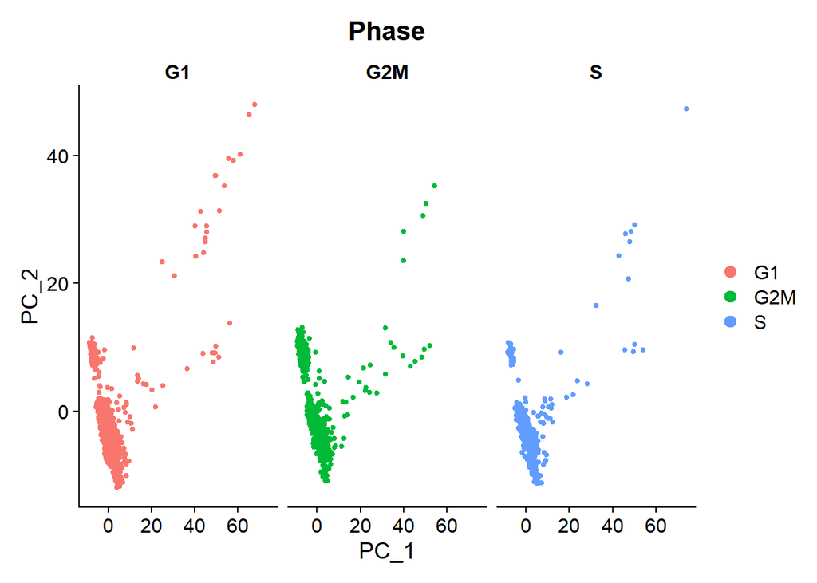

```r
# Plot the PCA, colored by cell cycle phase
DimPlot(cells_singlets_phase, reduction = "pca", split.by = "Phase", group.by = "Phase", pt.size = 1)
```

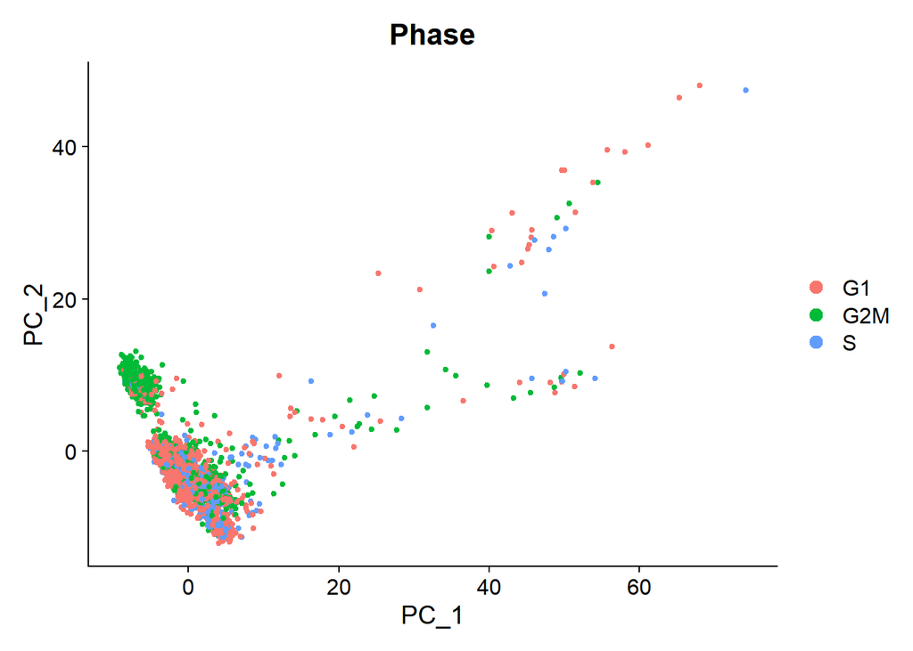

```r
DimPlot(cells_singlets_phase, reduction = "pca", group.by = "Phase" ,pt.size = 1)
```

## 4.2 Normalization and scTransform

- Final normalization is performed on the main Seurat object using SCTransform.
- Cell cycle scores are included as regression variables during SCTransform to reduce variation associated with cell cycle state. Although the dataset is expected to mainly consist of differentiated neurons, a small contribution of proliferating progenitor-like cells cannot be excluded.
- The cell cycle scores were used as regression variables during SCTransform. Although we expect our dataset consists of mainly differentiated neurons we cannot exclude a small contribution of progenitor cells.

```r
# Normalization, calculation of cell cycle scores and regressing out cell cycle variation during SCTransform
normalized_cells <- cells_singlets %>% NormalizeData(verbose = TRUE) %>%
CellCycleScoring(g2m.features = g2m_markers, s.features = s_markers) %>%
SCTransform(vars.to.regress = c("S.Score", "G2M.Score"))
```

```
## Normalizing layer: counts
```

```
## Running SCTransform on assay: RNA
```

```
## vst.flavor='v2' set. Using model with fixed slope and excluding poisson genes.
```

```
## Calculating cell attributes from input UMI matrix: log_umi
```

```
## Variance stabilizing transformation of count matrix of size 18861 by 3119
```

```
## Model formula is y ~ log_umi
```

```
## Get Negative Binomial regression parameters per gene
```

```
## Using 2000 genes, 3119 cells
```

```
## Found 36 outliers - those will be ignored in fitting/regularization step
```

```
## Second step: Get residuals using fitted parameters for 18861 genes
```

```
## Computing corrected count matrix for 18861 genes
```

```
## Wall clock passed: Time difference of 29.91635 secs
```

```
## Determine variable features
```

```
## Centering data matrix
```

```
## Place corrected count matrix in counts slot
```

```
## Set default assay to SCT
```

# 5. Standard Workflow and Clustering

```r
normalized_cells <- FindVariableFeatures(normalized_cells, selection.method = "vst", nfeatures = 2000, verbose = FALSE)
normalized_cells <- ScaleData(normalized_cells)
normalized_cells <- RunPCA(normalized_cells)
```

```
## PC_ 1
## Positive:  tmsb4x, marcksl1b, ptmaa, gpm6aa, hsp70.3, hsp70.2, nova2, stx1b, tuba1c, sv2a
##     stmn1b, si:ch211-222l21.1, gpm6ab, cspg5a, hsp70.1, elavl4, aplp1, elavl3, hsp90aa1.2, syt1a
##     sncb, hmgn2, RPL41, nrxn1a, appb, eef1a1l2, stmn2a, tuba1a, tubb5, scg2b
## Negative:  pde6c, prph2a, gnat2, gnb3b, pdcb, slc24a2, grk1b, tmem237a, rcvrn2, si:ch73-28h20.1
##     gngt2b, gc3, prph2b, cplx4a, opn1sw1, grk7a, sv2ba, atp2b1b, eno1b, rp1l1b
##     arr3b, cnga3a, tulp1a, guk1b, atp1b2b, ncaldb, si:ch1073-111c8.3, guca1c, rgs9a, si:ch1073-469d17.2
## PC_ 2
## Positive:  prdx1, zgc:56493, pou3f1, scgn, ctnnb1, CRACR2A, celf2, zgc:162707, ptprt, si:ch211-56a11.2
##     dlx5a, CR450824.2, si:dkeyp-110a12.4, otofa, txn, sox1a, nkx2.4b, si:ch211-131k2.2, rap1b, ak5l
##     lef1, nkx2.4a, tead1b, sox2, rgs8, zbtb20, th2, bsx, insm1a, prox1a
## Negative:  elavl4, gpm6ab, elavl3, stmn2a, stx1b, gpm6aa, maptb, kif1aa, aplp1, atp2b3a
##     sncb, sncgb, ptprub, syt1a, zfhx3, atp2b4, fxyd6, nell2b, tmsb2, syt2a
##     atp1a3a, nrxn1a, slc17a6b, ndrg4, clstn3, snap25a, scg2b, sv2a, slc2a3a, stmn1b
## PC_ 3
## Positive:  prdx1, pou3f1, gad2, ptprn2, msi2b, celf2, ptpn5, scgn, dlx5a, rgs8
##     CRACR2A, ak5l, CR450824.2, ptprt, ctnnb1, otofa, si:dkeyp-110a12.4, si:ch211-56a11.2, sox1a, zbtb20
##     slc32a1, zgc:162707, th2, ip6k2a, si:dkey-14k9.2, pou2f1b, CU467822.1, insm1b, nkx2.4a, nkx2.4b
## Negative:  eef1da, krt8, sepp1a, sparc, pmp22a, zgc:162730, col5a1, ahnak, col1a2, aldob
##     col1a1a, slc38a5b, col1a1b, lgals3b, krt4, si:ch211-105c13.3, cd63, mfap2, lxn, col2a1b
##     dcn, s100a10b, s100v2, FO904881.1, cebpd, gsta.1, col5a2a, fmoda, mxra8b, col6a2
## PC_ 4
## Positive:  slc6a2, phox2bb, dbh, phox2a, slc31a1, snap25a, mao, slc17a6b, syt2a, map1ab
##     cplx1, ngfra, hoxb3a, sall3a, frmpd3, tmsb, tfap2b, bdnf, fosab, hoxa4a
##     hoxb5a, atp1b1a, ENSDARG00000020655, raraa, hoxb5b, rgs4, kcnd3, fxyd6, rab6ba, CR812832.1
## Negative:  si:ch1073-70f20.1, tkta, rxraa, npnt, ENSDARG00000060631, tbx3a, nr4a2b, tspan18a, pth1ra, cavin1b
##     prl2, fam49a, cplx3a, kctd12.2, tmtc1, pappab, pax10, nrgna, TCIM, nr4a2a
##     nr2f2, slc38a3a, pax6b, cspg5b, FO704819.1, anos1a, tpm3, agap1, celf5a, lmo4b
## PC_ 5
## Positive:  col5a1, pmp22a, col1a2, col1a1b, col1a1a, sparc, mfap2, dcn, col2a1b, col6a2
##     col5a2a, col6a1, fmoda, mxra8b, col6a3, col6a4a, mmp14a, reck, pdgfra, plpp3
##     col11a1a, pdgfrl, si:ch211-286o17.1, aspn, col11a1b, serpinh1b, tpm4a, wnt11r, col4a2, mmp2
## Negative:  icn, krt4, FO904881.1, s100a10b, wu:fb18f06, s100w, zgc:153284, s100v1, si:dkey-248g15.3, si:ch211-105c13.3
##     gsto2, BX908782.1, tcnl, si:dkey-74k8.3, serpinb1, lgals2b, cnfn, fabp2, ENSDARG00000041339, tprg1
##     krt17.1, plac8.1, pfn1, prr13, serpinb1l3, s100a10a, cfl1l, gsta.2, zgc:101744, gstp2
```

```r
normalized_cells <- RunUMAP(normalized_cells, dims = 1:20, reduction = "pca", seed.use = 42L)
normalized_cells <- FindNeighbors(object = normalized_cells,
dims = 1:20)
normalized_cells <- FindClusters(object = normalized_cells, resolution = 1.0)
```

```
## Modularity Optimizer version 1.3.0 by Ludo Waltman and Nees Jan van Eck
##
## Number of nodes: 3119
## Number of edges: 90071
##
## Running Louvain algorithm...
## Maximum modularity in 10 random starts: 0.8865
## Number of communities: 23
## Elapsed time: 0 seconds
```

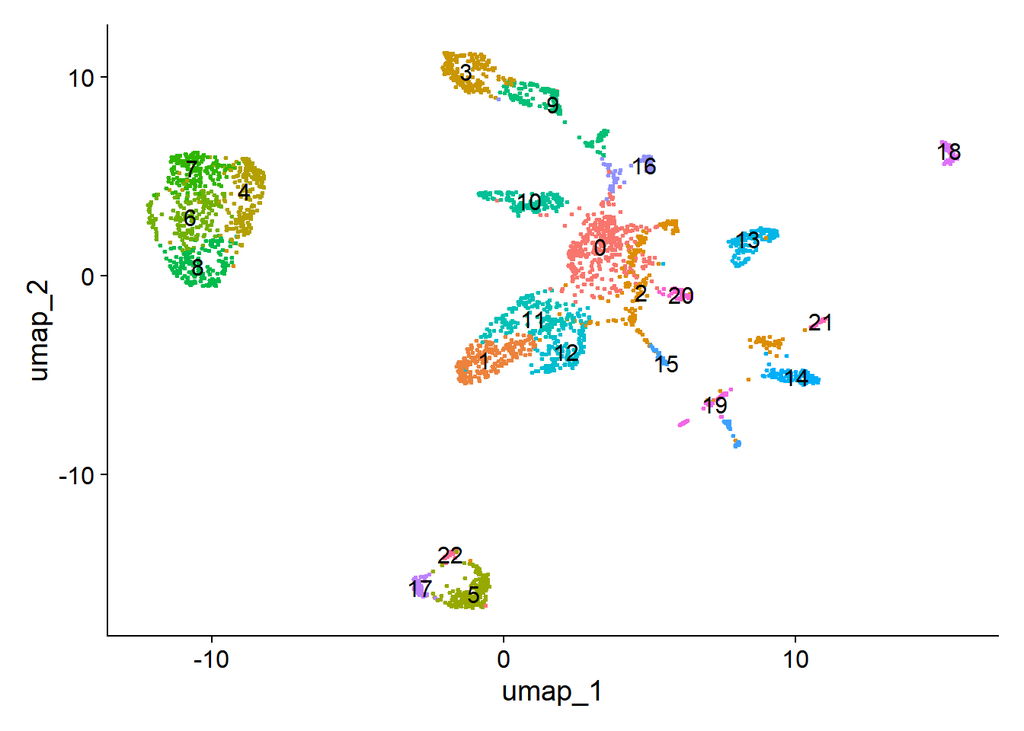

```r
DimPlot(normalized_cells, label = T) + NoLegend()
```

```r
Idents(object = normalized_cells) <- "SCT_snn_res.1"
```

# 6. Annotation

- Prior to annotation we performed DEG analysis (not included in this script) to identify cluster-specific genes. Using these results together with knowledge from previously published data we assigned the cluster identities.
- We used different visualizations for gene expression of such marker genes to evaluate the identities of our clusters.
- After annotation we repeated DEG analysis (see section 7) to acquire the data Table S1B is based on.

## 6.1 Hypothalamic DA Clusters

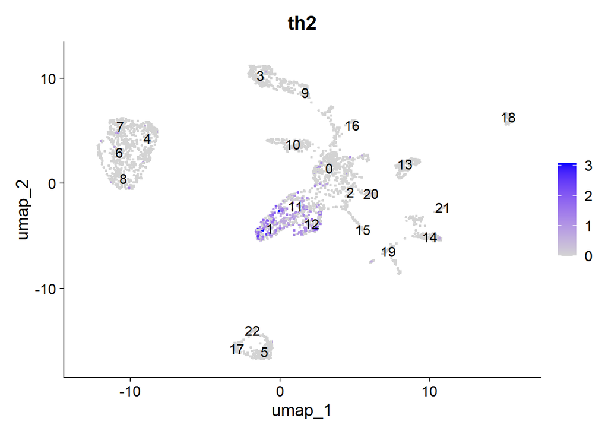

```r
FeaturePlot(normalized_cells, "th2", label = T)
```

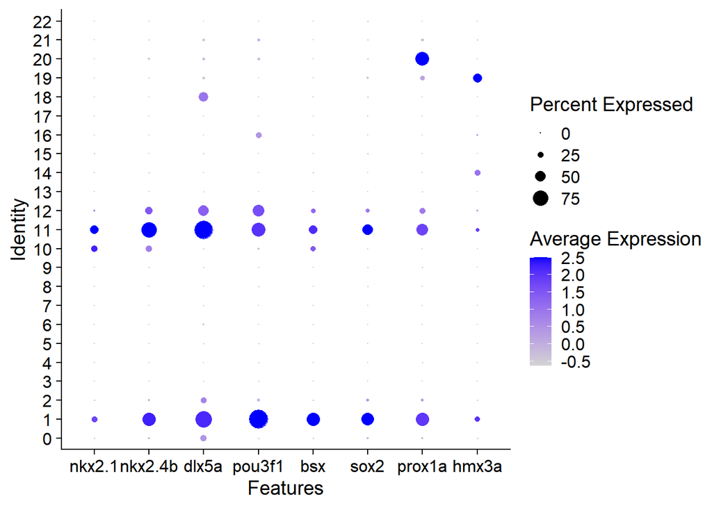

```r
DotPlot(normalized_cells, features = c("nkx2.1", "nkx2.4b", "dlx5a", "pou3f1", "bsx", "sox2", "prox1a", "hmx3a"))
```

## 6.2 Amacrine DA clusters

- Amacrine DA cells are described to express nr4a2b, nr4a2a, meis2a and tbx3a (Filippi et al., 2012; 10.1016/j.ydbio.2012.06.010)
- Due to the expression of these markers by cluster 5, 17, 22 were annotated as amacrine cell clusters
- Label: cl5 = Ama1, cl17 = Ama2, cl22 = Ama3

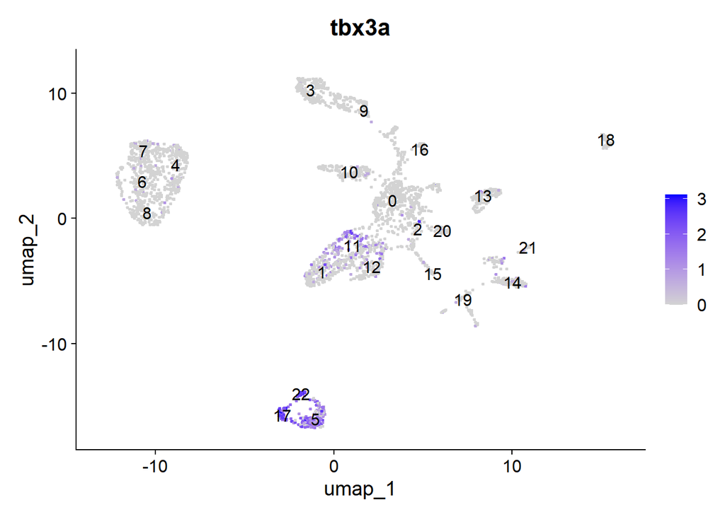

```r
FeaturePlot(normalized_cells, "tbx3a",label=T)
```

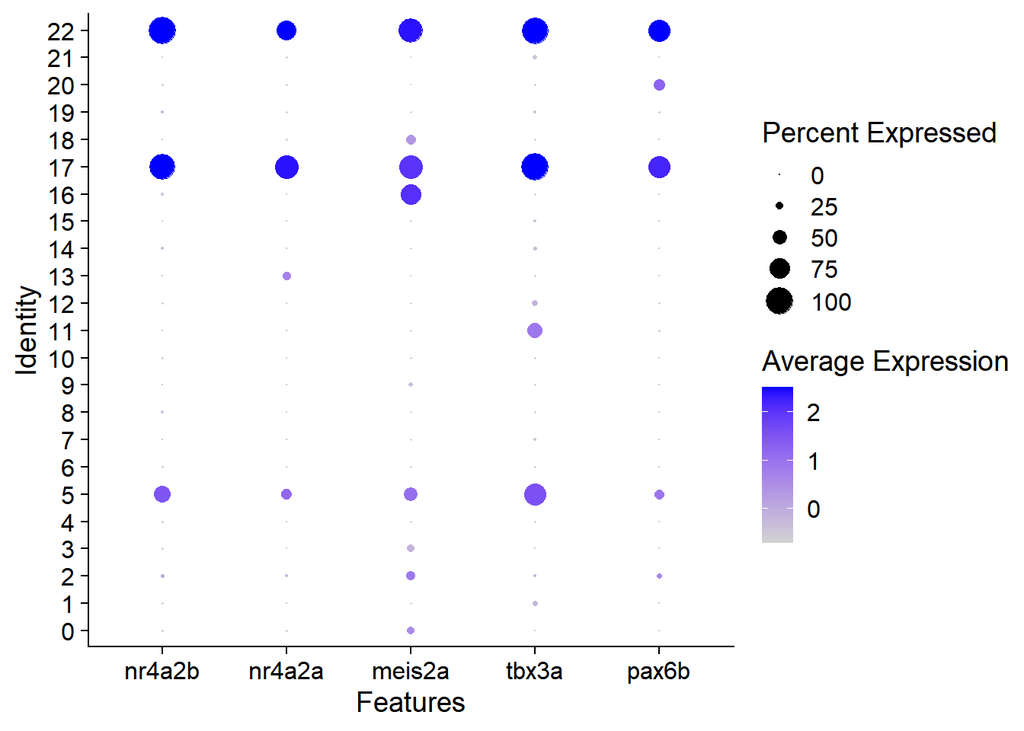

```r
DotPlot(normalized_cells, features = c("nr4a2b", "nr4a2a", "meis2a", "tbx3a", "pax6b"))
```

## 6.3 Pretectal DA clusters

- Pretectal cells express gata3, zic1, emx2, otx1b, nr4a2a, otx2, zic2a (Filippi et al., 2012; 10.1016/j.ydbio.2012.06.010)
- Based on the expression of these genes cluster 13 likely contains pretectal cells
- Label: cl13=PrT

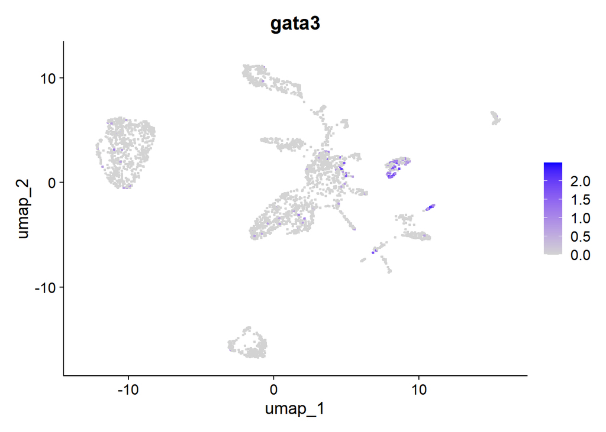

```r
FeaturePlot(normalized_cells, "gata3")
```

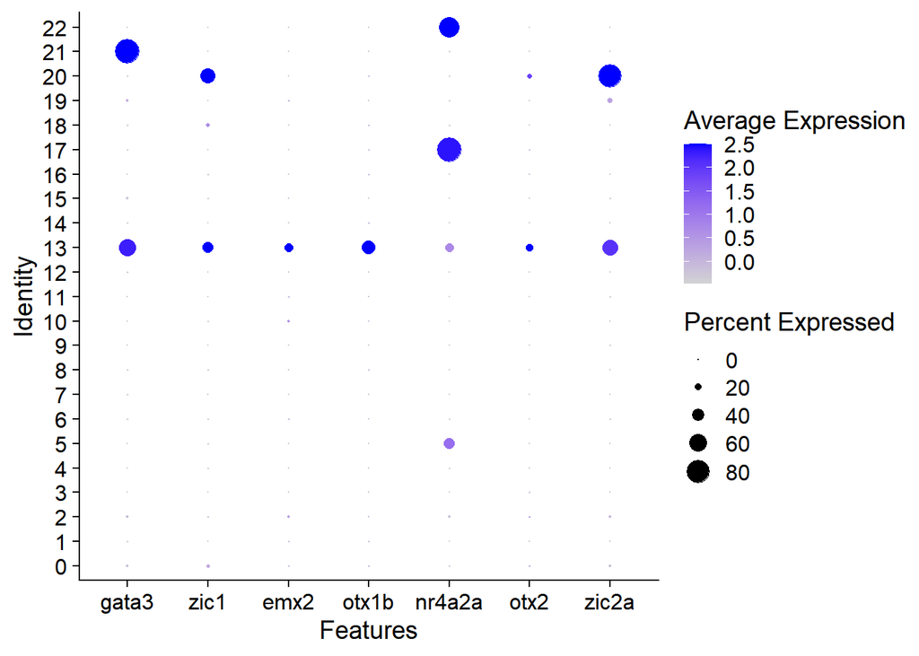

```r
DotPlot(normalized_cells, features = c("gata3", "zic1", "emx2","otx1b", "nr4a2a", "otx2","zic2a"))
```

## 6.4 PTub clusters (otp positive groups)

- otp DA clusters express otpa, otpb, sim1b, lhx1a , lhx1b, lhx5, nkx2.4b, nkx.2.1 (Filippi et al., 2012; 10.1016/j.ydbio.2012.06.010)
- Based on the expression of these genes cluster 10 consists of otp positive pTub DA neurons
- Label: cl10 = PTub

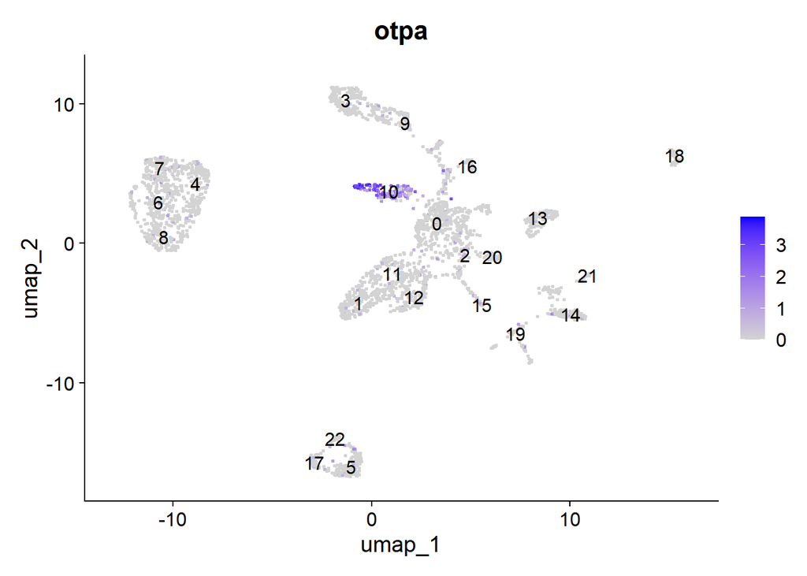

```r
FeaturePlot(normalized_cells, c("otpa"), label = T)
```

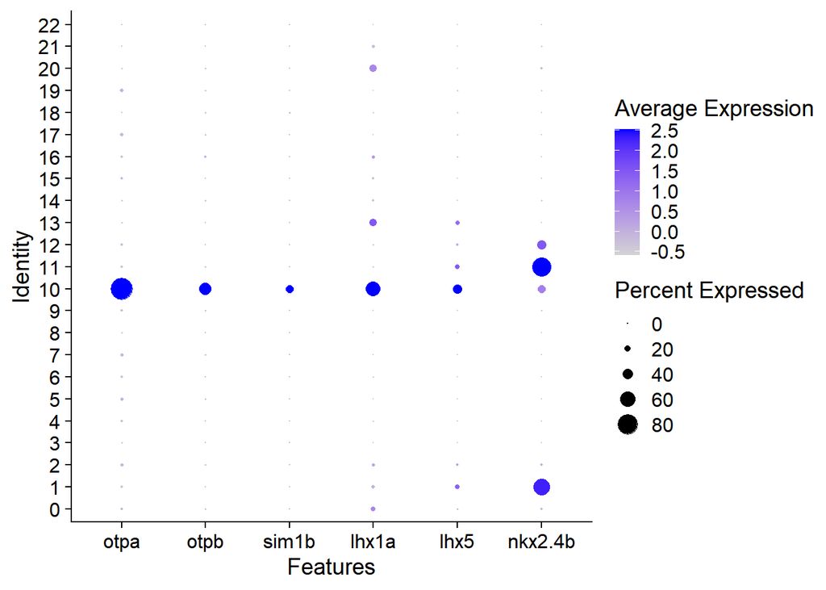

```r
DotPlot(normalized_cells, features = c("otpa", "otpb", "sim1b", "lhx1a", "lhx5", "nkx2.4b", "nkx.2.1"))
```

## 6.5 NA Hindbrain

- The NO MO / AP cells express dbh, tfap2a, tfap2b, lmx1bb, meis2a and are glutamatergic (Filippi et al., 2012; 10.1016/j.ydbio.2012.06.010)
- Based on the expression of these markers cluster 3 and 9 are probably NA Hindbrain clusters.
- Label: cl3 = Hb1, cl9 = Hb2

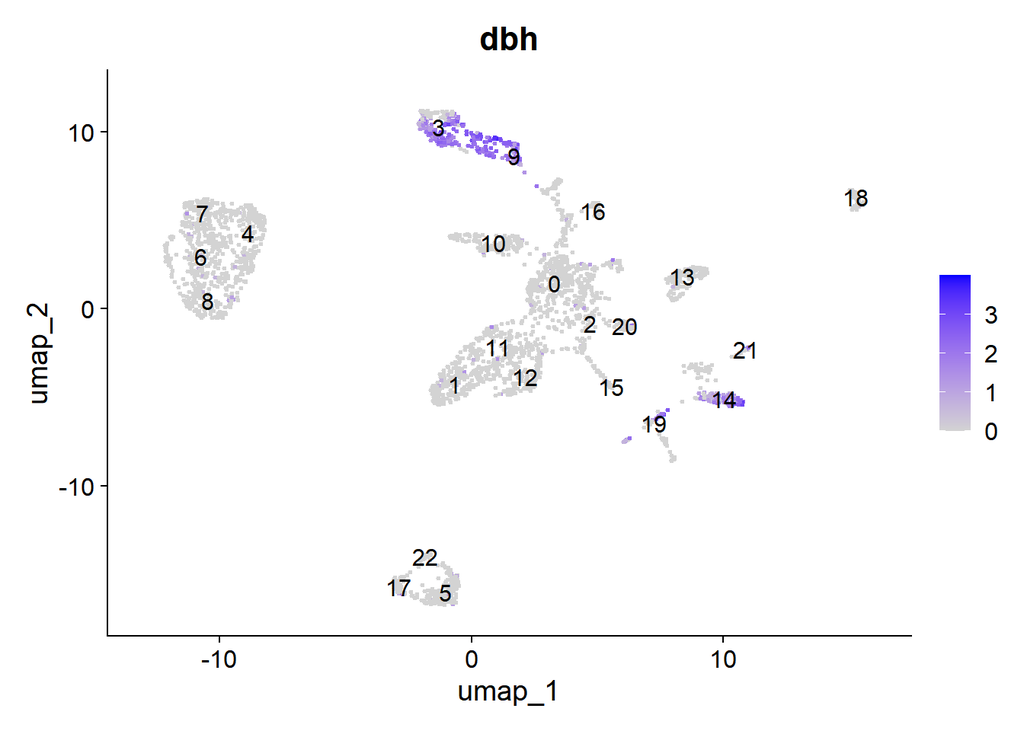

```r
FeaturePlot(normalized_cells, "dbh", label = T)
```

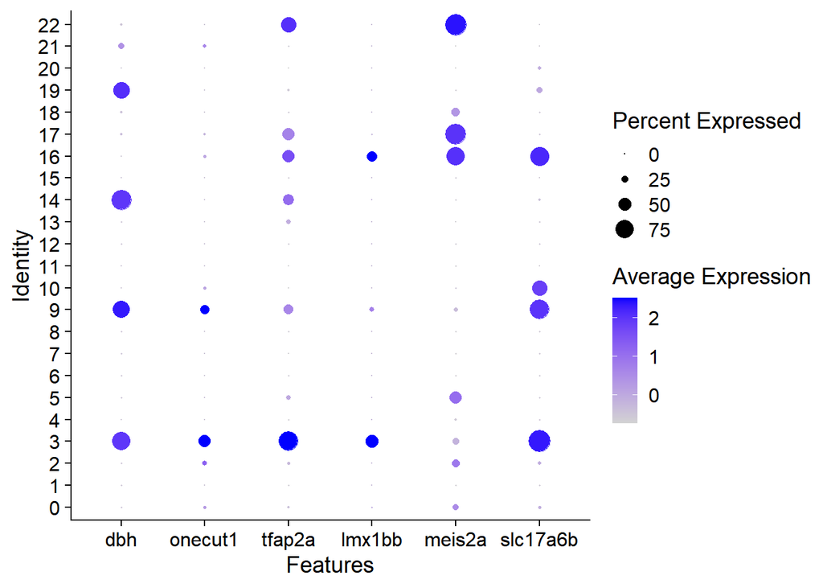

```r
DotPlot(normalized_cells, features = c("dbh", "onecut1", "tfap2a", "lmx1bb", "meis2a", "slc17a6b"))
```

## 6.6 Sympathetic / Peripheral NA clusters

- Markers to annotate sympathetic and or peripheral neurons are dbh, hand2, prph (Lucas et al., 2006; 10.1242/dev.02574)
- neuroepithelial cells of the gill express rgs5a, tph1a, sv2a, ndufa4l2a (Pan et al., 2022; 10.1038/s41598-022-13693-1)
- Thus, cluster 14 might represent peripheral neurons and cluster 19 neuroepithelial cells
- Label: cl14 = PN, cl19 = NEC

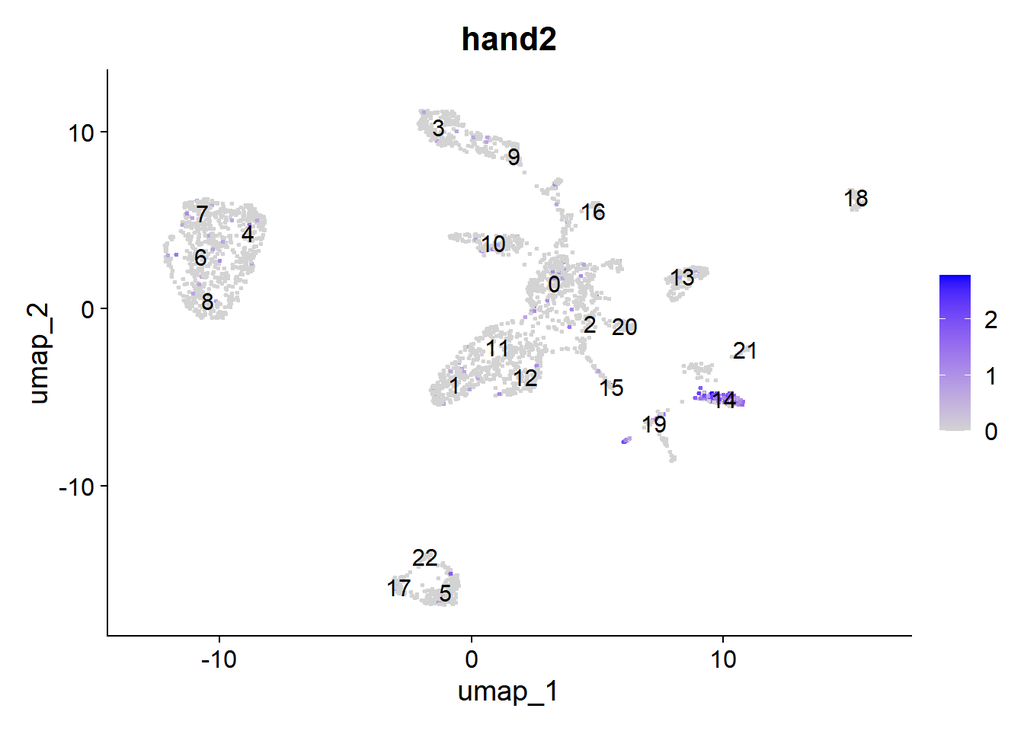

```r
FeaturePlot(normalized_cells, "hand2", label = T)
```

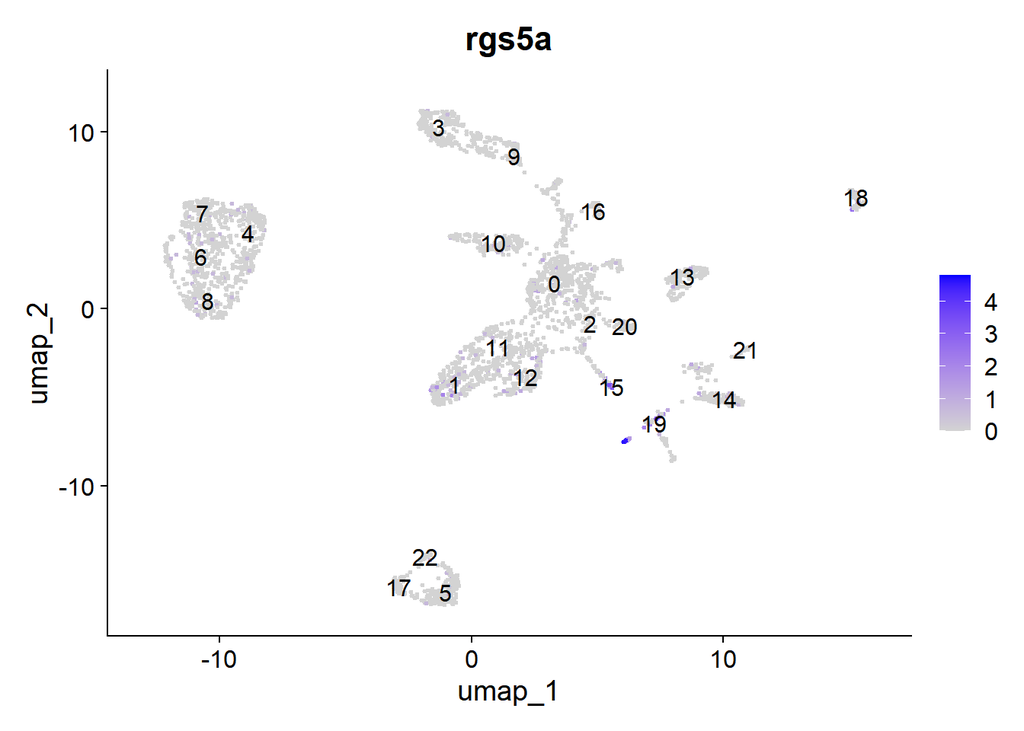

```r
FeaturePlot(normalized_cells, "rgs5a", label = T)
```

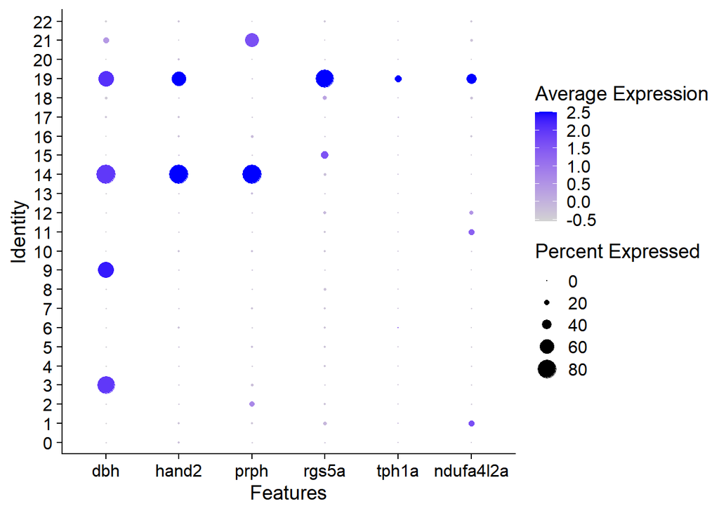

```r
DotPlot(normalized_cells, features = c("dbh","hand2", "prph", "rgs5a", "tph1a", "ndufa4l2a"))
```

## 6.7 OB DA cluster

- The olfactory bulb DA cells should express arx, dlx2a, dlx5a, etv1, pbx1a (Filippi et al., 2012; 10.1016/j.ydbio.2012.06.010)
- The olfactory bulb DA neurons also express sst7 (in the used genome annotation called sst3) (Armbruster et al., 2025; 10.1002/cne.70079)
- However, there is no cluster which expresses all of these markers. The DEG analysis showed that cluster 18 expresses synpr which we detected by our coexpression analysis to be expressed only in the OB DA cells and not in the EMeA at 5 dpf.
- Cluster 18 is thus likely composed of OB cells
- Label: Cl18 = OB

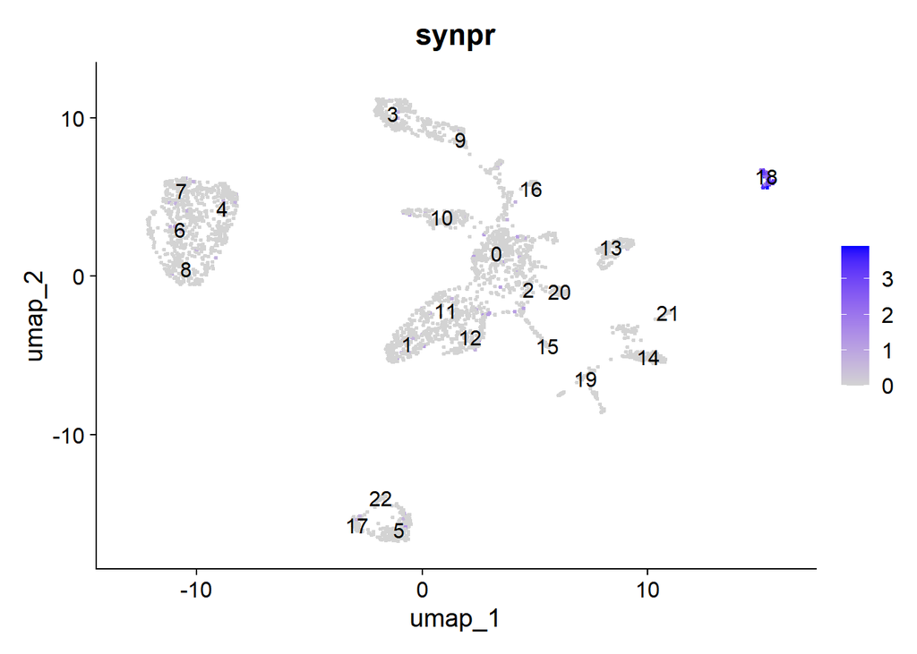

```r
FeaturePlot(normalized_cells, "synpr", label = T)
```

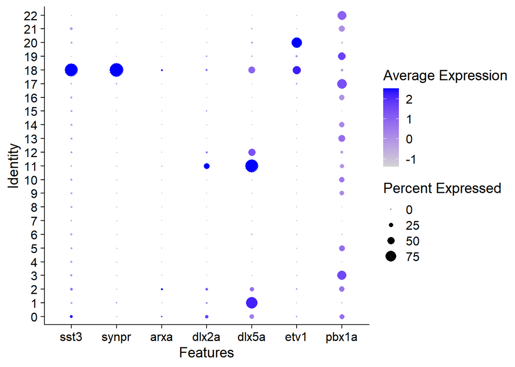

```r
DotPlot(normalized_cells, features = c("sst3", "synpr", "arxa","dlx2a", "dlx5a", "etv1", "pbx1a"))
```

## 6.8 ventral forebrain cluster (vFB/Prog1 + vFB/Prog2)

- Cluster 0 and 2 express several ventral forebrain markers e.g. dlx genes that however, could not be assigned to specific anatomical regions. Few cells in this clusters also express progenitor markers and hindbrain markers. We decided to annote them as vFb/Prog1 and vFb/Prog2.
- We will try to dissect further identities in these clusters using an integrative approach in Script 5+6.
- Label cl0 = vFb/Prog1, cl2 = vFb/Prog2

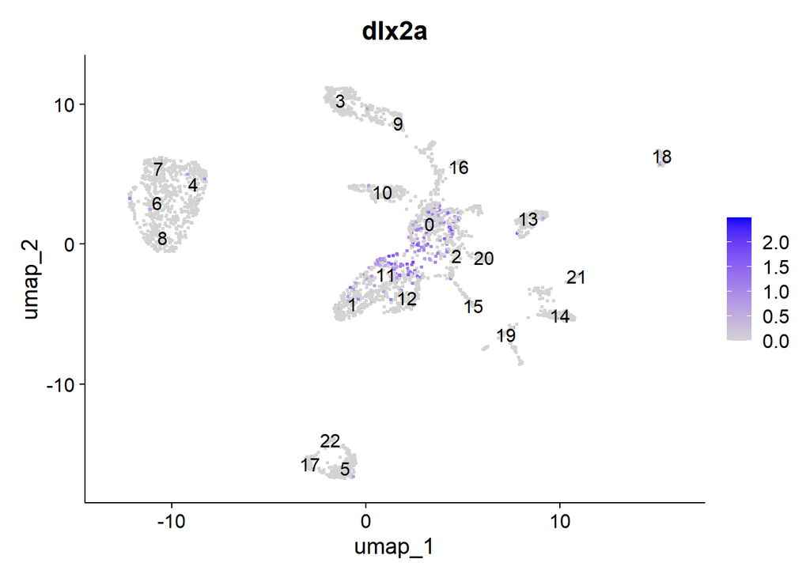

```r
FeaturePlot(normalized_cells, "dlx2a", label = T)
```

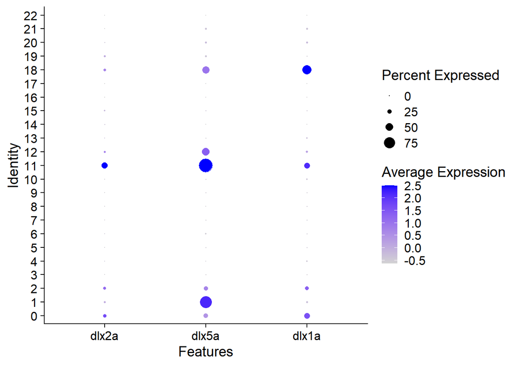

```r
DotPlot(normalized_cells, features = c("dlx2a", "dlx5a", "dlx1a"))
```

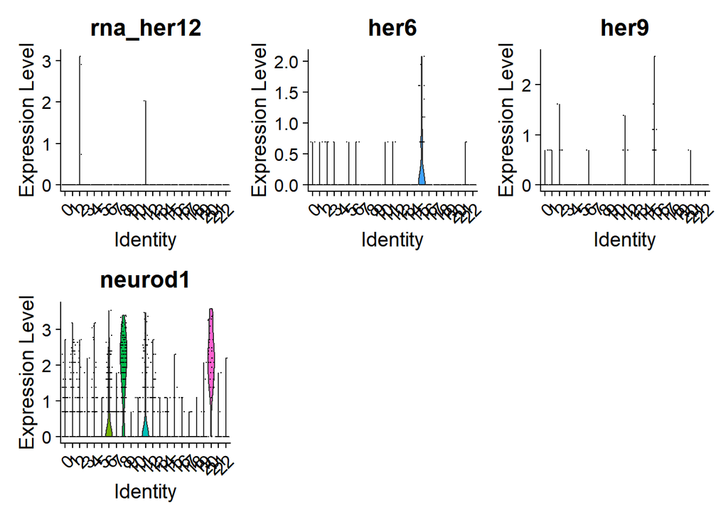

```r
VlnPlot(normalized_cells, features = c("her12", "her6", "her9", "neurod1"))
```

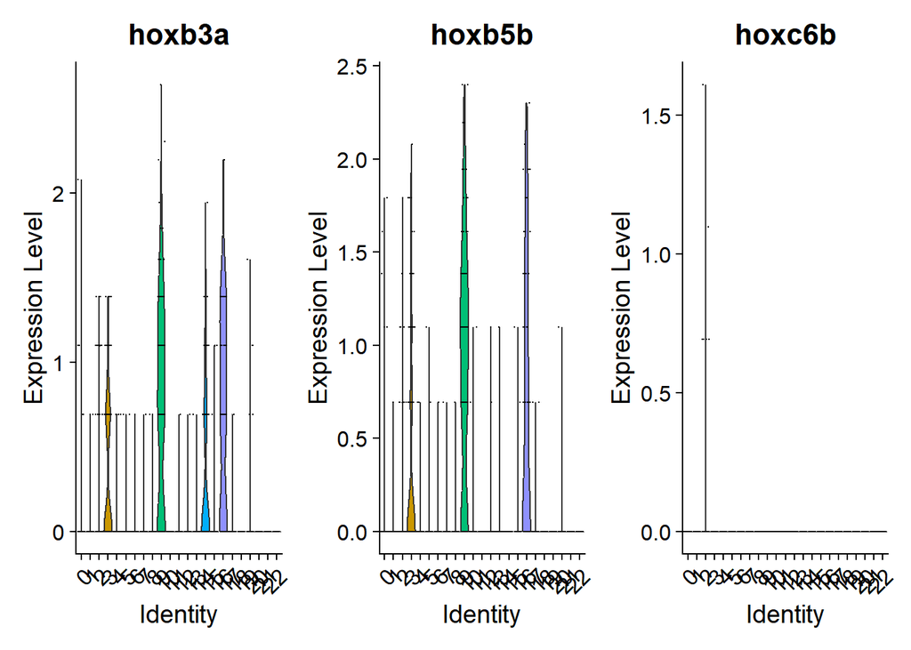

```r
VlnPlot(normalized_cells, features = c("hoxb3a", "hoxb5b", "hoxc6b"))
```

## 6.9 Hindbrain cluster with low / undetected dbh levels

- Cluster 16 shows signatures for hindbrain cells, but lacks the expression of dbh. Genes upregulated are e.g. pou4f1, hoxb2a, hoxb3a
- Thus cluster 16 might be another hindbrain cluster with low / absent dbh expression.
- Label cl16 = Hb3

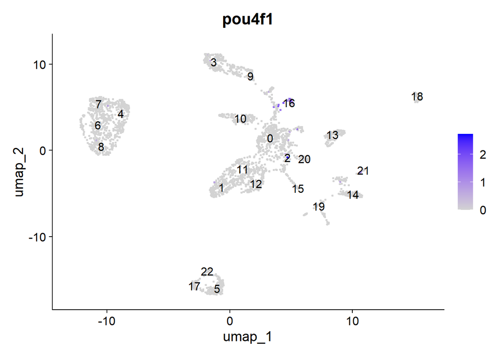

```r
FeaturePlot(normalized_cells, "pou4f1", label = T)
```

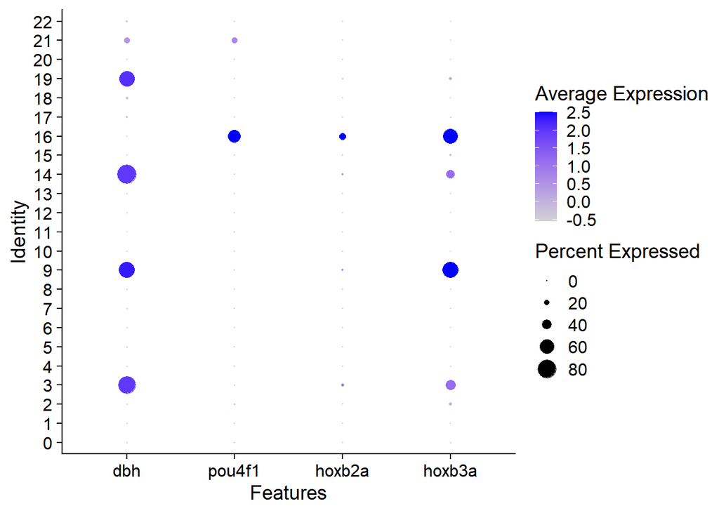

```r
DotPlot(normalized_cells, features = c("dbh", "pou4f1","hoxb2a", "hoxb3a"))
```

## 6.10 Motor nucleus of the vagus nerve (DMX)

- In mouse whole brain scRNAseq data a subclass of cells in the dorsal motor nucleus of the vagus nerve (DMX) shows expression of Chat and Tbx20 (10.1038/s41586-023-06812-z)
- In zebrafish the DMX should be isl1 positive as this gene is required for motor neuron differenitation. (Ericson et al., 1992, 10.1126/science.1350865; Higashijima et al., 2000, 10.1523/JNEUROSCI.20-01-00206.2000)
- Cluster 21 expresses tbx20, chata and isl1 and might represents such DMX neurons
- Label: Cl21 = DMX

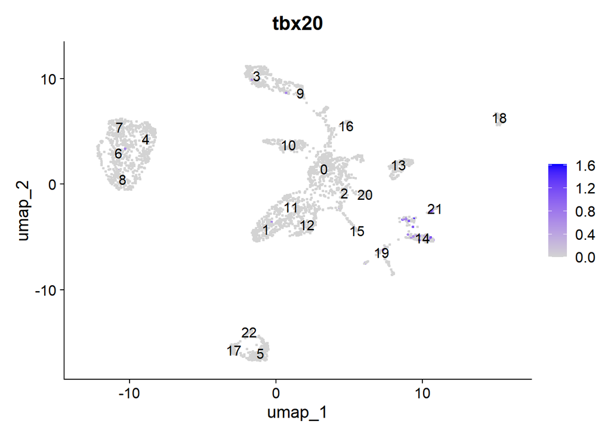

```r
FeaturePlot(normalized_cells, "tbx20", label = T)
```

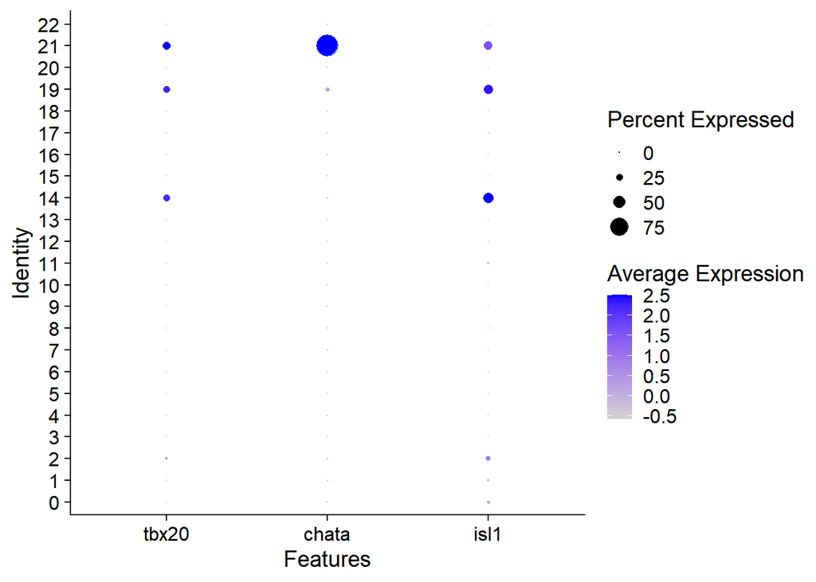

```r
DotPlot(normalized_cells, features = c("tbx20", "chata","isl1"))
```

## 6.11 Cerebellar cells

- Cluster 20 shows upregulation of genes associated with cerebellar cells such as en1, en2, etv1, neurod1 and nfia (Schüller et al., 2006; 10.1016/j.mcn.2006.07.010)
- Previously, th-positive cells in the rostral hindbrain have been desribed to be marked by the thm1512Tg(2A−QF2); Tg(QUASr:GFP)c403 reporter line used in this study (Altbürger et al., 10.3389/fnana.2023.1196868)
- Thus cluster 20 was annotated as cerebellar cells.
- Label: cl20 = Cb

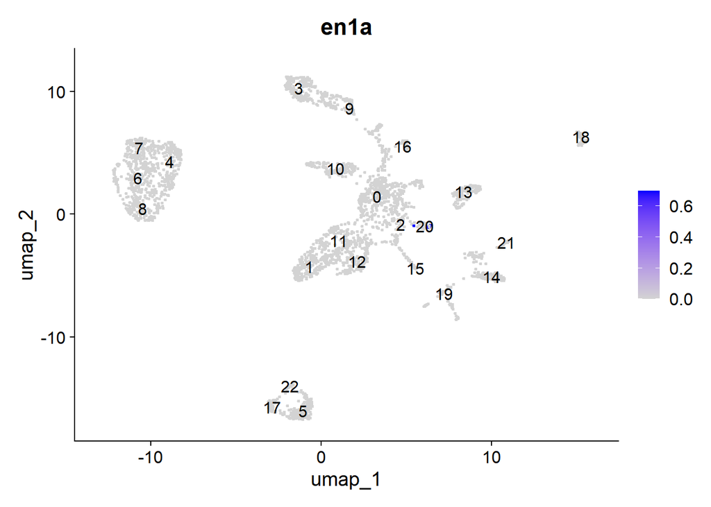

```r
FeaturePlot(normalized_cells, "en1a", label = T)
```

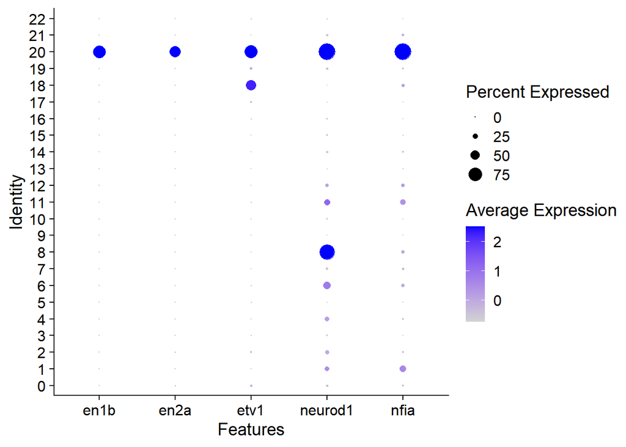

```r
DotPlot(normalized_cells, features = c("en1b", "en2a", "etv1", "neurod1", "nfia"))
```

## 6.12 Retinal cells

- Cluster 4,6,7,8 show strong expression of tulp1a which is known to be expressed by retinal photoreceptor cells in zebrafish (Liu et al., 2022; 10.1371/journal.pgen.1009841)
- As these clusters neither express CA nor neural markers we suggest that we potentially also co-enriched retinal photoreceptor cells. The low-level EGFP expression in these cells might derive from EGFP ambient RNA induced during library preparation.
- Cluster 4,6,7,8 were labelled as retinal photoreceptor cells
- Label: cl4 = Ret1, cl6 = Ret2, cl7 = Re3, cl8 = Re4

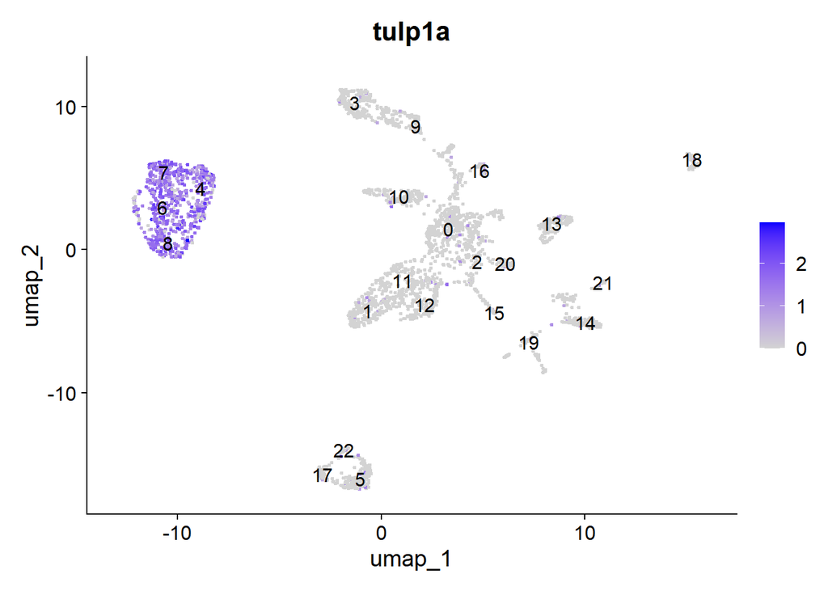

```r
FeaturePlot(normalized_cells, "tulp1a", label = T)
```

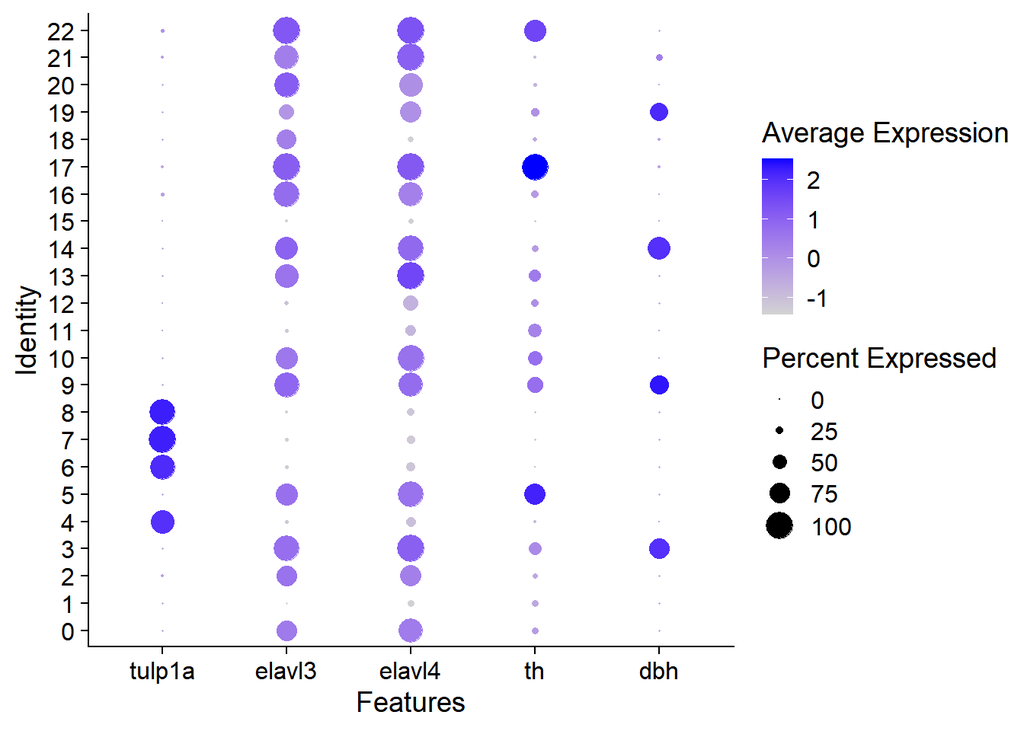

```r
DotPlot(normalized_cells, features = c("tulp1a", "elavl3", "elavl4", "th", "dbh"))
```

## 6.13 Endothelial

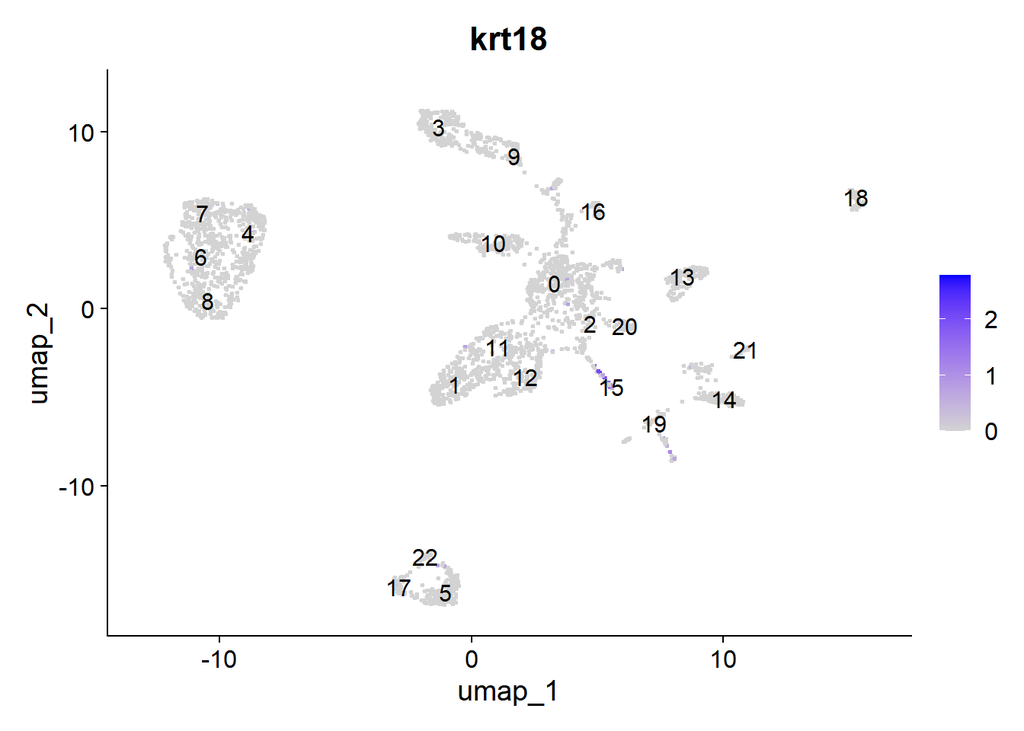

```r
FeaturePlot(normalized_cells, "krt18", label = T)
```

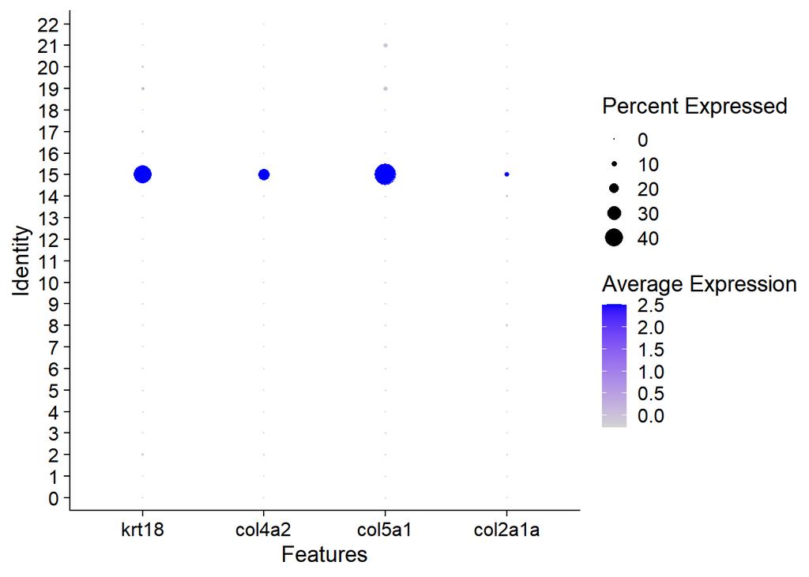

```r
DotPlot(normalized_cells, features = c("krt18", "col4a2", "col5a1", "col2a1a"))
```